# Risk Factor Analysis

## Outcome Variable

**Outcome Variable:** sstunted

## Predictor Variables

**Intervention Variable:** parity

**Adjustment Set:**

- arm
- W_mage
- meducyrs
- feducyrs
- hhwealth_quart
- W_mhtcm
- W_mwtkg
- W_mbmi
- vagbrth
- W_nrooms
- impsan
- delta_W_mage
- delta_meducyrs
- delta_feducyrs
- delta_hhwealth_quart
- delta_W_mhtcm
- delta_W_mwtkg
- delta_W_mbmi
- delta_vagbrth
- delta_W_nrooms
- delta_impsan

## Stratifying Variables

The analysis was stratified on these variable(s):

- agecat
- studyid
- country

## Data Summary

| agecat | studyid | country | parity | sstunted | n_cell | n |
| --- | --- | --- | --- | --- | --- | --- |
| Birth | ki1000304b-SAS-CompFeed | INDIA | 1 | 0 | 334 | 1252 |
| Birth | ki1000304b-SAS-CompFeed | INDIA | 1 | 1 | 27 | 1252 |
| Birth | ki1000304b-SAS-CompFeed | INDIA | 2 | 0 | 269 | 1252 |
| Birth | ki1000304b-SAS-CompFeed | INDIA | 2 | 1 | 20 | 1252 |
| Birth | ki1000304b-SAS-CompFeed | INDIA | 3+ | 0 | 558 | 1252 |
| Birth | ki1000304b-SAS-CompFeed | INDIA | 3+ | 1 | 44 | 1252 |
| Birth | ki1017093b-PROVIDE | BANGLADESH | 1 | 0 | 204 | 539 |
| Birth | ki1017093b-PROVIDE | BANGLADESH | 1 | 1 | 2 | 539 |
| Birth | ki1017093b-PROVIDE | BANGLADESH | 2 | 0 | 183 | 539 |
| Birth | ki1017093b-PROVIDE | BANGLADESH | 2 | 1 | 0 | 539 |
| Birth | ki1017093b-PROVIDE | BANGLADESH | 3+ | 0 | 148 | 539 |
| Birth | ki1017093b-PROVIDE | BANGLADESH | 3+ | 1 | 2 | 539 |
| Birth | ki1101329-Keneba | GAMBIA | 1 | 0 | 153 | 1407 |
| Birth | ki1101329-Keneba | GAMBIA | 1 | 1 | 3 | 1407 |
| Birth | ki1101329-Keneba | GAMBIA | 2 | 0 | 144 | 1407 |
| Birth | ki1101329-Keneba | GAMBIA | 2 | 1 | 2 | 1407 |
| Birth | ki1101329-Keneba | GAMBIA | 3+ | 0 | 1084 | 1407 |
| Birth | ki1101329-Keneba | GAMBIA | 3+ | 1 | 21 | 1407 |
| Birth | ki1113344-GMS-Nepal | NEPAL | 1 | 0 | 196 | 696 |
| Birth | ki1113344-GMS-Nepal | NEPAL | 1 | 1 | 15 | 696 |
| Birth | ki1113344-GMS-Nepal | NEPAL | 2 | 0 | 175 | 696 |
| Birth | ki1113344-GMS-Nepal | NEPAL | 2 | 1 | 5 | 696 |
| Birth | ki1113344-GMS-Nepal | NEPAL | 3+ | 0 | 294 | 696 |
| Birth | ki1113344-GMS-Nepal | NEPAL | 3+ | 1 | 11 | 696 |
| Birth | ki1126311-ZVITAMBO | ZIMBABWE | 1 | 0 | 5794 | 13874 |
| Birth | ki1126311-ZVITAMBO | ZIMBABWE | 1 | 1 | 195 | 13874 |
| Birth | ki1126311-ZVITAMBO | ZIMBABWE | 2 | 0 | 4040 | 13874 |
| Birth | ki1126311-ZVITAMBO | ZIMBABWE | 2 | 1 | 104 | 13874 |
| Birth | ki1126311-ZVITAMBO | ZIMBABWE | 3+ | 0 | 3598 | 13874 |
| Birth | ki1126311-ZVITAMBO | ZIMBABWE | 3+ | 1 | 143 | 13874 |

[output cut: 144 more lines]

The following strata were considered:

- agecat: 24 months, studyid: ki1017093b-PROVIDE, country: BANGLADESH
- agecat: 24 months, studyid: ki1066203-TanzaniaChild2, country: TANZANIA, UNITED REPUBLIC OF
- agecat: 24 months, studyid: ki1101329-Keneba, country: GAMBIA
- agecat: 24 months, studyid: ki1113344-GMS-Nepal, country: NEPAL
- agecat: 24 months, studyid: ki1126311-ZVITAMBO, country: ZIMBABWE
- agecat: 24 months, studyid: ki1135781-COHORTS, country: GUATEMALA
- agecat: 24 months, studyid: ki1135781-COHORTS, country: INDIA
- agecat: 24 months, studyid: ki1135781-COHORTS, country: PHILIPPINES
- agecat: 24 months, studyid: kiGH5241-JiVitA-3, country: BANGLADESH
- agecat: 6 months, studyid: ki1000304b-SAS-CompFeed, country: INDIA
- agecat: 6 months, studyid: ki1000304b-SAS-FoodSuppl, country: INDIA
- agecat: 6 months, studyid: ki1017093b-PROVIDE, country: BANGLADESH
- agecat: 6 months, studyid: ki1066203-TanzaniaChild2, country: TANZANIA, UNITED REPUBLIC OF
- agecat: 6 months, studyid: ki1101329-Keneba, country: GAMBIA
- agecat: 6 months, studyid: ki1113344-GMS-Nepal, country: NEPAL
- agecat: 6 months, studyid: ki1126311-ZVITAMBO, country: ZIMBABWE
- agecat: 6 months, studyid: ki1135781-COHORTS, country: GUATEMALA
- agecat: 6 months, studyid: ki1135781-COHORTS, country: INDIA
- agecat: 6 months, studyid: ki1135781-COHORTS, country: PHILIPPINES
- agecat: 6 months, studyid: kiGH5241-JiVitA-3, country: BANGLADESH
- agecat: Birth, studyid: ki1000304b-SAS-CompFeed, country: INDIA
- agecat: Birth, studyid: ki1017093b-PROVIDE, country: BANGLADESH
- agecat: Birth, studyid: ki1101329-Keneba, country: GAMBIA
- agecat: Birth, studyid: ki1113344-GMS-Nepal, country: NEPAL
- agecat: Birth, studyid: ki1126311-ZVITAMBO, country: ZIMBABWE
- agecat: Birth, studyid: ki1135781-COHORTS, country: GUATEMALA
- agecat: Birth, studyid: ki1135781-COHORTS, country: INDIA
- agecat: Birth, studyid: ki1135781-COHORTS, country: PHILIPPINES
- agecat: Birth, studyid: kiGH5241-JiVitA-3, country: BANGLADESH

### Dropped Strata

Some strata were dropped due to rare outcomes:

- agecat: Birth, studyid: ki1017093b-PROVIDE, country: BANGLADESH
- agecat: Birth, studyid: ki1101329-Keneba, country: GAMBIA
- agecat: Birth, studyid: ki1135781-COHORTS, country: GUATEMALA
- agecat: 6 months, studyid: ki1000304b-SAS-FoodSuppl, country: INDIA
- agecat: 6 months, studyid: ki1017093b-PROVIDE, country: BANGLADESH
- agecat: 6 months, studyid: ki1066203-TanzaniaChild2, country: TANZANIA, UNITED REPUBLIC OF
- agecat: 6 months, studyid: ki1101329-Keneba, country: GAMBIA
- agecat: 24 months, studyid: ki1066203-TanzaniaChild2, country: TANZANIA, UNITED REPUBLIC OF

## Methods Detail

We’re interested in the causal parameters $E[Y_a]$ for all values of $a \in \mathcal{A}$. These parameters represent the mean outcome if, possibly contrary to fact, we intervened to set all units to have $A=a$. Under the randomization and positivity assumptions, these are identified by the statistical parameters $\psi_a=E_W[E_{Y|A,W}(Y|A=a,W)]$. In addition, we’re interested in the mean of $Y$, $E[Y]$ under no intervention (the observed mean). We will estimate these parameters by using SuperLearner to fit the relevant likelihood factors – $E_{Y|A,W}(Y|A=a,W)$ and $p(A=a|W)$, and then updating our likelihood fit using a joint TMLE.

For unadjusted analyses ($W=\{\}$), initial likelihoods were estimated using Lrnr_glm to estimate the simple $E(Y|A)$ and Lrnr_mean to estimate $p(A)$. For adjusted analyses, a small library containing Lrnr_glmnet, Lrnr_xgboost, and Lrnr_mean was used.

Having estimated these parameters, we will then use the delta method to estimate relative risks and attributable risks relative to a prespecified baseline level of $A$.

# Results Detail

## Results Plots

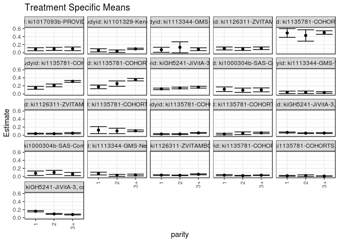

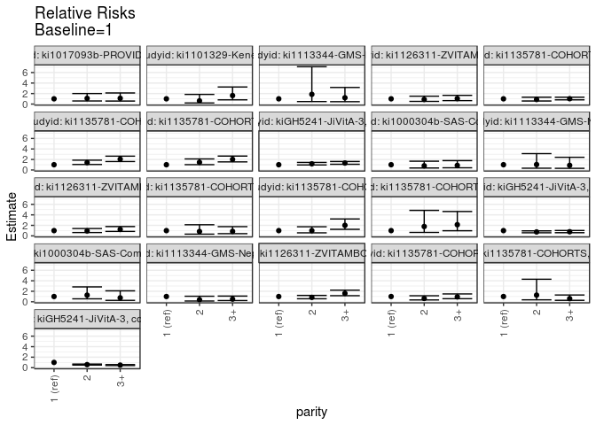

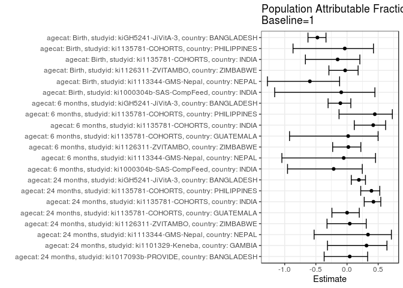

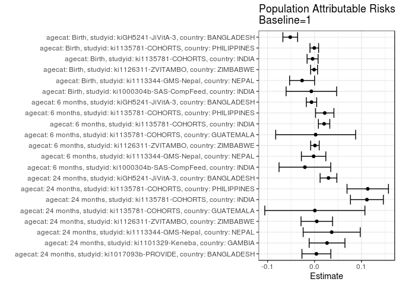

## Results Table

### Parameter: TSM

| agecat | studyid | country | intervention_level | baseline_level | estimate | ci_lower | ci_upper |
| --- | --- | --- | --- | --- | --- | --- | --- |
| Birth | ki1000304b-SAS-CompFeed | INDIA | 1 | NA | 0.0794299 | 0.0247399 | 0.1341199 |
| Birth | ki1000304b-SAS-CompFeed | INDIA | 2 | NA | 0.1000590 | 0.0485154 | 0.1516026 |
| Birth | ki1000304b-SAS-CompFeed | INDIA | 3+ | NA | 0.0596398 | 0.0199262 | 0.0993533 |
| Birth | ki1113344-GMS-Nepal | NEPAL | 1 | NA | 0.0710900 | 0.0363916 | 0.1057885 |
| Birth | ki1113344-GMS-Nepal | NEPAL | 2 | NA | 0.0277778 | 0.0037532 | 0.0518023 |
| Birth | ki1113344-GMS-Nepal | NEPAL | 3+ | NA | 0.0360656 | 0.0151254 | 0.0570058 |
| Birth | ki1126311-ZVITAMBO | ZIMBABWE | 1 | NA | 0.0328173 | 0.0248578 | 0.0407768 |
| Birth | ki1126311-ZVITAMBO | ZIMBABWE | 2 | NA | 0.0273413 | 0.0197047 | 0.0349778 |
| Birth | ki1126311-ZVITAMBO | ZIMBABWE | 3+ | NA | 0.0524859 | 0.0412791 | 0.0636927 |
| Birth | ki1135781-COHORTS | INDIA | 1 | NA | 0.0315460 | 0.0185094 | 0.0445826 |
| Birth | ki1135781-COHORTS | INDIA | 2 | NA | 0.0199416 | 0.0114531 | 0.0284301 |
| Birth | ki1135781-COHORTS | INDIA | 3+ | NA | 0.0294321 | 0.0226662 | 0.0361980 |
| Birth | ki1135781-COHORTS | PHILIPPINES | 1 | NA | 0.0156288 | 0.0054834 | 0.0257742 |
| Birth | ki1135781-COHORTS | PHILIPPINES | 2 | NA | 0.0197555 | -0.0006961 | 0.0402071 |
| Birth | ki1135781-COHORTS | PHILIPPINES | 3+ | NA | 0.0092904 | 0.0053547 | 0.0132261 |
| Birth | kiGH5241-JiVitA-3 | BANGLADESH | 1 | NA | 0.1607806 | 0.1442008 | 0.1773604 |
| Birth | kiGH5241-JiVitA-3 | BANGLADESH | 2 | NA | 0.0937748 | 0.0826100 | 0.1049395 |
| Birth | kiGH5241-JiVitA-3 | BANGLADESH | 3+ | NA | 0.0789124 | 0.0679747 | 0.0898501 |
| 6 months | ki1000304b-SAS-CompFeed | INDIA | 1 | NA | 0.1163526 | 0.0589468 | 0.1737585 |
| 6 months | ki1000304b-SAS-CompFeed | INDIA | 2 | NA | 0.0922177 | 0.0385571 | 0.1458784 |
| 6 months | ki1000304b-SAS-CompFeed | INDIA | 3+ | NA | 0.1004848 | 0.0517072 | 0.1492624 |
| 6 months | ki1113344-GMS-Nepal | NEPAL | 1 | NA | 0.0392157 | 0.0084313 | 0.0700001 |
| 6 months | ki1113344-GMS-Nepal | NEPAL | 2 | NA | 0.0402685 | 0.0086750 | 0.0718620 |
| 6 months | ki1113344-GMS-Nepal | NEPAL | 3+ | NA | 0.0343511 | 0.0122781 | 0.0564242 |
| 6 months | ki1126311-ZVITAMBO | ZIMBABWE | 1 | NA | 0.0396153 | 0.0296828 | 0.0495477 |
| 6 months | ki1126311-ZVITAMBO | ZIMBABWE | 2 | NA | 0.0374081 | 0.0260764 | 0.0487398 |
| 6 months | ki1126311-ZVITAMBO | ZIMBABWE | 3+ | NA | 0.0486013 | 0.0353962 | 0.0618064 |
| 6 months | ki1135781-COHORTS | GUATEMALA | 1 | NA | 0.1266213 | 0.0398883 | 0.2133542 |
| 6 months | ki1135781-COHORTS | GUATEMALA | 2 | NA | 0.1054643 | 0.0387628 | 0.1721657 |
| 6 months | ki1135781-COHORTS | GUATEMALA | 3+ | NA | 0.1088380 | 0.0868022 | 0.1308737 |
| 6 months | ki1135781-COHORTS | INDIA | 1 | NA | 0.0280953 | 0.0156686 | 0.0405220 |
| 6 months | ki1135781-COHORTS | INDIA | 2 | NA | 0.0280632 | 0.0188092 | 0.0373173 |
| 6 months | ki1135781-COHORTS | INDIA | 3+ | NA | 0.0562712 | 0.0465065 | 0.0660359 |
| 6 months | ki1135781-COHORTS | PHILIPPINES | 1 | NA | 0.0269975 | 0.0073082 | 0.0466867 |
| 6 months | ki1135781-COHORTS | PHILIPPINES | 2 | NA | 0.0481086 | 0.0149205 | 0.0812966 |
| 6 months | ki1135781-COHORTS | PHILIPPINES | 3+ | NA | 0.0574608 | 0.0414135 | 0.0735080 |
| 6 months | kiGH5241-JiVitA-3 | BANGLADESH | 1 | NA | 0.0671263 | 0.0551314 | 0.0791213 |
| 6 months | kiGH5241-JiVitA-3 | BANGLADESH | 2 | NA | 0.0504791 | 0.0422954 | 0.0586628 |
| 6 months | kiGH5241-JiVitA-3 | BANGLADESH | 3+ | NA | 0.0529612 | 0.0430037 | 0.0629187 |
| 24 months | ki1017093b-PROVIDE | BANGLADESH | 1 | NA | 0.0860295 | 0.0480034 | 0.1240556 |
| 24 months | ki1017093b-PROVIDE | BANGLADESH | 2 | NA | 0.0934057 | 0.0534761 | 0.1333353 |
| 24 months | ki1017093b-PROVIDE | BANGLADESH | 3+ | NA | 0.0947083 | 0.0494933 | 0.1399234 |
| 24 months | ki1101329-Keneba | GAMBIA | 1 | NA | 0.0583942 | 0.0191148 | 0.0976736 |
| 24 months | ki1101329-Keneba | GAMBIA | 2 | NA | 0.0359712 | 0.0050027 | 0.0669398 |
| 24 months | ki1101329-Keneba | GAMBIA | 3+ | NA | 0.0945455 | 0.0772488 | 0.1118422 |
| 24 months | ki1113344-GMS-Nepal | NEPAL | 1 | NA | 0.0720142 | 0.0091599 | 0.1348686 |
| 24 months | ki1113344-GMS-Nepal | NEPAL | 2 | NA | 0.1332670 | -0.0034804 | 0.2700144 |
| 24 months | ki1113344-GMS-Nepal | NEPAL | 3+ | NA | 0.0864595 | 0.0502608 | 0.1226581 |
| 24 months | ki1126311-ZVITAMBO | ZIMBABWE | 1 | NA | 0.1037968 | 0.0672521 | 0.1403414 |
| 24 months | ki1126311-ZVITAMBO | ZIMBABWE | 2 | NA | 0.0910141 | 0.0539666 | 0.1280616 |
| 24 months | ki1126311-ZVITAMBO | ZIMBABWE | 3+ | NA | 0.1086305 | 0.0761297 | 0.1411314 |
| 24 months | ki1135781-COHORTS | GUATEMALA | 1 | NA | 0.4889954 | 0.3790026 | 0.5989881 |
| 24 months | ki1135781-COHORTS | GUATEMALA | 2 | NA | 0.4277291 | 0.2862764 | 0.5691817 |
| 24 months | ki1135781-COHORTS | GUATEMALA | 3+ | NA | 0.5005845 | 0.4563574 | 0.5448116 |
| 24 months | ki1135781-COHORTS | INDIA | 1 | NA | 0.1514194 | 0.1155194 | 0.1873195 |
| 24 months | ki1135781-COHORTS | INDIA | 2 | NA | 0.2115811 | 0.1762336 | 0.2469285 |
| 24 months | ki1135781-COHORTS | INDIA | 3+ | NA | 0.3111055 | 0.2881883 | 0.3340227 |
| 24 months | ki1135781-COHORTS | PHILIPPINES | 1 | NA | 0.1757649 | 0.1304121 | 0.2211177 |
| 24 months | ki1135781-COHORTS | PHILIPPINES | 2 | NA | 0.2560936 | 0.1892222 | 0.3229650 |
| 24 months | ki1135781-COHORTS | PHILIPPINES | 3+ | NA | 0.3548854 | 0.3242200 | 0.3855508 |
| 24 months | kiGH5241-JiVitA-3 | BANGLADESH | 1 | NA | 0.1263308 | 0.1074883 | 0.1451734 |
| 24 months | kiGH5241-JiVitA-3 | BANGLADESH | 2 | NA | 0.1478503 | 0.1269135 | 0.1687871 |
| 24 months | kiGH5241-JiVitA-3 | BANGLADESH | 3+ | NA | 0.1670552 | 0.1455076 | 0.1886027 |

### Parameter: E(Y)

| agecat | studyid | country | intervention_level | baseline_level | estimate | ci_lower | ci_upper |
| --- | --- | --- | --- | --- | --- | --- | --- |
| Birth | ki1000304b-SAS-CompFeed | INDIA | NA | NA | 0.0726837 | 0.0523147 | 0.0930527 |
| Birth | ki1113344-GMS-Nepal | NEPAL | NA | NA | 0.0445402 | 0.0292033 | 0.0598771 |
| Birth | ki1126311-ZVITAMBO | ZIMBABWE | NA | NA | 0.0318582 | 0.0289357 | 0.0347806 |
| Birth | ki1135781-COHORTS | INDIA | NA | NA | 0.0274139 | 0.0224285 | 0.0323992 |
| Birth | ki1135781-COHORTS | PHILIPPINES | NA | NA | 0.0150820 | 0.0107558 | 0.0194081 |
| Birth | kiGH5241-JiVitA-3 | BANGLADESH | NA | NA | 0.1090180 | 0.1044666 | 0.1135695 |
| 6 months | ki1000304b-SAS-CompFeed | INDIA | NA | NA | 0.0958084 | 0.0774939 | 0.1141229 |
| 6 months | ki1113344-GMS-Nepal | NEPAL | NA | NA | 0.0372340 | 0.0215945 | 0.0528736 |
| 6 months | ki1126311-ZVITAMBO | ZIMBABWE | NA | NA | 0.0404938 | 0.0363439 | 0.0446436 |
| 6 months | ki1135781-COHORTS | GUATEMALA | NA | NA | 0.1290323 | 0.1078261 | 0.1502385 |
| 6 months | ki1135781-COHORTS | INDIA | NA | NA | 0.0484735 | 0.0420469 | 0.0549002 |
| 6 months | ki1135781-COHORTS | PHILIPPINES | NA | NA | 0.0487445 | 0.0406327 | 0.0568562 |
| 6 months | kiGH5241-JiVitA-3 | BANGLADESH | NA | NA | 0.0606746 | 0.0568229 | 0.0645262 |
| 24 months | ki1017093b-PROVIDE | BANGLADESH | NA | NA | 0.0899654 | 0.0666186 | 0.1133122 |
| 24 months | ki1101329-Keneba | GAMBIA | NA | NA | 0.0850291 | 0.0702861 | 0.0997720 |
| 24 months | ki1113344-GMS-Nepal | NEPAL | NA | NA | 0.1086066 | 0.0809724 | 0.1362407 |
| 24 months | ki1126311-ZVITAMBO | ZIMBABWE | NA | NA | 0.1086028 | 0.0935351 | 0.1236705 |
| 24 months | ki1135781-COHORTS | GUATEMALA | NA | NA | 0.4896617 | 0.4596107 | 0.5197126 |
| 24 months | ki1135781-COHORTS | INDIA | NA | NA | 0.2630178 | 0.2481729 | 0.2778626 |
| 24 months | ki1135781-COHORTS | PHILIPPINES | NA | NA | 0.2891616 | 0.2711872 | 0.3071359 |
| 24 months | kiGH5241-JiVitA-3 | BANGLADESH | NA | NA | 0.1560473 | 0.1472898 | 0.1648047 |

### Parameter: RR

| agecat | studyid | country | intervention_level | baseline_level | estimate | ci_lower | ci_upper |
| --- | --- | --- | --- | --- | --- | --- | --- |
| Birth | ki1000304b-SAS-CompFeed | INDIA | 1 | 1 | 1.0000000 | 1.0000000 | 1.0000000 |
| Birth | ki1000304b-SAS-CompFeed | INDIA | 2 | 1 | 1.2597152 | 0.5597490 | 2.8349889 |
| Birth | ki1000304b-SAS-CompFeed | INDIA | 3+ | 1 | 0.7508480 | 0.2708168 | 2.0817493 |
| Birth | ki1113344-GMS-Nepal | NEPAL | 1 | 1 | 1.0000000 | 1.0000000 | 1.0000000 |
| Birth | ki1113344-GMS-Nepal | NEPAL | 2 | 1 | 0.3907407 | 0.1447400 | 1.0548458 |
| Birth | ki1113344-GMS-Nepal | NEPAL | 3+ | 1 | 0.5073224 | 0.2376100 | 1.0831868 |
| Birth | ki1126311-ZVITAMBO | ZIMBABWE | 1 | 1 | 1.0000000 | 1.0000000 | 1.0000000 |
| Birth | ki1126311-ZVITAMBO | ZIMBABWE | 2 | 1 | 0.8331362 | 0.5755448 | 1.2060154 |
| Birth | ki1126311-ZVITAMBO | ZIMBABWE | 3+ | 1 | 1.5993360 | 1.1578210 | 2.2092151 |
| Birth | ki1135781-COHORTS | INDIA | 1 | 1 | 1.0000000 | 1.0000000 | 1.0000000 |
| Birth | ki1135781-COHORTS | INDIA | 2 | 1 | 0.6321443 | 0.3492672 | 1.1441281 |
| Birth | ki1135781-COHORTS | INDIA | 3+ | 1 | 0.9329894 | 0.5814539 | 1.4970563 |
| Birth | ki1135781-COHORTS | PHILIPPINES | 1 | 1 | 1.0000000 | 1.0000000 | 1.0000000 |
| Birth | ki1135781-COHORTS | PHILIPPINES | 2 | 1 | 1.2640481 | 0.3723069 | 4.2916682 |
| Birth | ki1135781-COHORTS | PHILIPPINES | 3+ | 1 | 0.5944418 | 0.2736246 | 1.2914081 |
| Birth | kiGH5241-JiVitA-3 | BANGLADESH | 1 | 1 | 1.0000000 | 1.0000000 | 1.0000000 |
| Birth | kiGH5241-JiVitA-3 | BANGLADESH | 2 | 1 | 0.5832467 | 0.4966287 | 0.6849719 |
| Birth | kiGH5241-JiVitA-3 | BANGLADESH | 3+ | 1 | 0.4908078 | 0.4119926 | 0.5847004 |
| 6 months | ki1000304b-SAS-CompFeed | INDIA | 1 | 1 | 1.0000000 | 1.0000000 | 1.0000000 |
| 6 months | ki1000304b-SAS-CompFeed | INDIA | 2 | 1 | 0.7925712 | 0.3764194 | 1.6688012 |
| 6 months | ki1000304b-SAS-CompFeed | INDIA | 3+ | 1 | 0.8636230 | 0.4184301 | 1.7824834 |
| 6 months | ki1113344-GMS-Nepal | NEPAL | 1 | 1 | 1.0000000 | 1.0000000 | 1.0000000 |
| 6 months | ki1113344-GMS-Nepal | NEPAL | 2 | 1 | 1.0268456 | 0.3384548 | 3.1153701 |
| 6 months | ki1113344-GMS-Nepal | NEPAL | 3+ | 1 | 0.8759542 | 0.3176197 | 2.4157685 |
| 6 months | ki1126311-ZVITAMBO | ZIMBABWE | 1 | 1 | 1.0000000 | 1.0000000 | 1.0000000 |
| 6 months | ki1126311-ZVITAMBO | ZIMBABWE | 2 | 1 | 0.9442861 | 0.6373690 | 1.3989954 |
| 6 months | ki1126311-ZVITAMBO | ZIMBABWE | 3+ | 1 | 1.2268325 | 0.8477556 | 1.7754150 |
| 6 months | ki1135781-COHORTS | GUATEMALA | 1 | 1 | 1.0000000 | 1.0000000 | 1.0000000 |
| 6 months | ki1135781-COHORTS | GUATEMALA | 2 | 1 | 0.8329109 | 0.3277421 | 2.1167270 |
| 6 months | ki1135781-COHORTS | GUATEMALA | 3+ | 1 | 0.8595551 | 0.4208682 | 1.7555019 |
| 6 months | ki1135781-COHORTS | INDIA | 1 | 1 | 1.0000000 | 1.0000000 | 1.0000000 |
| 6 months | ki1135781-COHORTS | INDIA | 2 | 1 | 0.9988591 | 0.5755365 | 1.7335468 |
| 6 months | ki1135781-COHORTS | INDIA | 3+ | 1 | 2.0028713 | 1.2455119 | 3.2207587 |
| 6 months | ki1135781-COHORTS | PHILIPPINES | 1 | 1 | 1.0000000 | 1.0000000 | 1.0000000 |
| 6 months | ki1135781-COHORTS | PHILIPPINES | 2 | 1 | 1.7819665 | 0.6541182 | 4.8544815 |
| 6 months | ki1135781-COHORTS | PHILIPPINES | 3+ | 1 | 2.1283778 | 0.9761507 | 4.6406688 |
| 6 months | kiGH5241-JiVitA-3 | BANGLADESH | 1 | 1 | 1.0000000 | 1.0000000 | 1.0000000 |
| 6 months | kiGH5241-JiVitA-3 | BANGLADESH | 2 | 1 | 0.7520014 | 0.5911808 | 0.9565704 |
| 6 months | kiGH5241-JiVitA-3 | BANGLADESH | 3+ | 1 | 0.7889784 | 0.6059604 | 1.0272732 |
| 24 months | ki1017093b-PROVIDE | BANGLADESH | 1 | 1 | 1.0000000 | 1.0000000 | 1.0000000 |
| 24 months | ki1017093b-PROVIDE | BANGLADESH | 2 | 1 | 1.0857401 | 0.5867962 | 2.0089285 |
| 24 months | ki1017093b-PROVIDE | BANGLADESH | 3+ | 1 | 1.1008820 | 0.5739100 | 2.1117271 |
| 24 months | ki1101329-Keneba | GAMBIA | 1 | 1 | 1.0000000 | 1.0000000 | 1.0000000 |
| 24 months | ki1101329-Keneba | GAMBIA | 2 | 1 | 0.6160075 | 0.2065845 | 1.8368524 |
| 24 months | ki1101329-Keneba | GAMBIA | 3+ | 1 | 1.6190909 | 0.8063563 | 3.2509887 |
| 24 months | ki1113344-GMS-Nepal | NEPAL | 1 | 1 | 1.0000000 | 1.0000000 | 1.0000000 |
| 24 months | ki1113344-GMS-Nepal | NEPAL | 2 | 1 | 1.8505649 | 0.4819388 | 7.1058618 |
| 24 months | ki1113344-GMS-Nepal | NEPAL | 3+ | 1 | 1.2005887 | 0.4552109 | 3.1664736 |
| 24 months | ki1126311-ZVITAMBO | ZIMBABWE | 1 | 1 | 1.0000000 | 1.0000000 | 1.0000000 |
| 24 months | ki1126311-ZVITAMBO | ZIMBABWE | 2 | 1 | 0.8768492 | 0.5122988 | 1.5008127 |
| 24 months | ki1126311-ZVITAMBO | ZIMBABWE | 3+ | 1 | 1.0465695 | 0.6595038 | 1.6608057 |
| 24 months | ki1135781-COHORTS | GUATEMALA | 1 | 1 | 1.0000000 | 1.0000000 | 1.0000000 |
| 24 months | ki1135781-COHORTS | GUATEMALA | 2 | 1 | 0.8747099 | 0.5865296 | 1.3044822 |
| 24 months | ki1135781-COHORTS | GUATEMALA | 3+ | 1 | 1.0236999 | 0.8045870 | 1.3024838 |
| 24 months | ki1135781-COHORTS | INDIA | 1 | 1 | 1.0000000 | 1.0000000 | 1.0000000 |
| 24 months | ki1135781-COHORTS | INDIA | 2 | 1 | 1.3973178 | 1.0463538 | 1.8660007 |
| 24 months | ki1135781-COHORTS | INDIA | 3+ | 1 | 2.0545941 | 1.6041847 | 2.6314657 |
| 24 months | ki1135781-COHORTS | PHILIPPINES | 1 | 1 | 1.0000000 | 1.0000000 | 1.0000000 |
| 24 months | ki1135781-COHORTS | PHILIPPINES | 2 | 1 | 1.4570234 | 1.0108743 | 2.1000804 |
| 24 months | ki1135781-COHORTS | PHILIPPINES | 3+ | 1 | 2.0190908 | 1.5402623 | 2.6467750 |
| 24 months | kiGH5241-JiVitA-3 | BANGLADESH | 1 | 1 | 1.0000000 | 1.0000000 | 1.0000000 |
| 24 months | kiGH5241-JiVitA-3 | BANGLADESH | 2 | 1 | 1.1703423 | 0.9540606 | 1.4356542 |
| 24 months | kiGH5241-JiVitA-3 | BANGLADESH | 3+ | 1 | 1.3223627 | 1.0833692 | 1.6140786 |

### Parameter: PAR

| agecat | studyid | country | intervention_level | baseline_level | estimate | ci_lower | ci_upper |
| --- | --- | --- | --- | --- | --- | --- | --- |
| Birth | ki1000304b-SAS-CompFeed | INDIA | 1 | NA | -0.0067462 | -0.0605906 | 0.0470983 |
| Birth | ki1113344-GMS-Nepal | NEPAL | 1 | NA | -0.0265498 | -0.0531807 | 0.0000811 |
| Birth | ki1126311-ZVITAMBO | ZIMBABWE | 1 | NA | -0.0009591 | -0.0083574 | 0.0064391 |
| Birth | ki1135781-COHORTS | INDIA | 1 | NA | -0.0041321 | -0.0158638 | 0.0075996 |
| Birth | ki1135781-COHORTS | PHILIPPINES | 1 | NA | -0.0005468 | -0.0097402 | 0.0086466 |
| Birth | kiGH5241-JiVitA-3 | BANGLADESH | 1 | NA | -0.0517626 | -0.0674637 | -0.0360615 |
| 6 months | ki1000304b-SAS-CompFeed | INDIA | 1 | NA | -0.0205442 | -0.0756305 | 0.0345420 |
| 6 months | ki1113344-GMS-Nepal | NEPAL | 1 | NA | -0.0019816 | -0.0280222 | 0.0240589 |
| 6 months | ki1126311-ZVITAMBO | ZIMBABWE | 1 | NA | 0.0008785 | -0.0082023 | 0.0099593 |
| 6 months | ki1135781-COHORTS | GUATEMALA | 1 | NA | 0.0024110 | -0.0827611 | 0.0875831 |
| 6 months | ki1135781-COHORTS | INDIA | 1 | NA | 0.0203783 | 0.0082469 | 0.0325096 |
| 6 months | ki1135781-COHORTS | PHILIPPINES | 1 | NA | 0.0217470 | 0.0021924 | 0.0413017 |
| 6 months | kiGH5241-JiVitA-3 | BANGLADESH | 1 | NA | -0.0064518 | -0.0174919 | 0.0045884 |
| 24 months | ki1017093b-PROVIDE | BANGLADESH | 1 | NA | 0.0039359 | -0.0268170 | 0.0346888 |
| 24 months | ki1101329-Keneba | GAMBIA | 1 | NA | 0.0266349 | -0.0114833 | 0.0647531 |
| 24 months | ki1113344-GMS-Nepal | NEPAL | 1 | NA | 0.0365923 | -0.0242406 | 0.0974252 |
| 24 months | ki1126311-ZVITAMBO | ZIMBABWE | 1 | NA | 0.0048061 | -0.0287784 | 0.0383905 |
| 24 months | ki1135781-COHORTS | GUATEMALA | 1 | NA | 0.0006663 | -0.1060204 | 0.1073530 |
| 24 months | ki1135781-COHORTS | INDIA | 1 | NA | 0.1115983 | 0.0765515 | 0.1466451 |
| 24 months | ki1135781-COHORTS | PHILIPPINES | 1 | NA | 0.1133966 | 0.0692333 | 0.1575600 |
| 24 months | kiGH5241-JiVitA-3 | BANGLADESH | 1 | NA | 0.0297164 | 0.0118635 | 0.0475694 |

### Parameter: PAF

| agecat | studyid | country | intervention_level | baseline_level | estimate | ci_lower | ci_upper |
| --- | --- | --- | --- | --- | --- | --- | --- |
| Birth | ki1000304b-SAS-CompFeed | INDIA | 1 | NA | -0.0928154 | -1.1609686 | 0.4473564 |
| Birth | ki1113344-GMS-Nepal | NEPAL | 1 | NA | -0.5960862 | -1.2770413 | -0.1187725 |
| Birth | ki1126311-ZVITAMBO | ZIMBABWE | 1 | NA | -0.0301067 | -0.2906033 | 0.1778111 |
| Birth | ki1135781-COHORTS | INDIA | 1 | NA | -0.1507303 | -0.6678427 | 0.2060522 |
| Birth | ki1135781-COHORTS | PHILIPPINES | 1 | NA | -0.0362559 | -0.8663278 | 0.4246314 |
| Birth | kiGH5241-JiVitA-3 | BANGLADESH | 1 | NA | -0.4748075 | -0.6264314 | -0.3373187 |
| 6 months | ki1000304b-SAS-CompFeed | INDIA | 1 | NA | -0.2144306 | -0.9545500 | 0.2454316 |
| 6 months | ki1113344-GMS-Nepal | NEPAL | 1 | NA | -0.0532213 | -1.0453620 | 0.4576632 |
| 6 months | ki1126311-ZVITAMBO | ZIMBABWE | 1 | NA | 0.0216951 | -0.2303153 | 0.2220853 |
| 6 months | ki1135781-COHORTS | GUATEMALA | 1 | NA | 0.0186850 | -0.9225275 | 0.4991078 |
| 6 months | ki1135781-COHORTS | INDIA | 1 | NA | 0.4203998 | 0.1166554 | 0.6196995 |
| 6 months | ki1135781-COHORTS | PHILIPPINES | 1 | NA | 0.4461432 | -0.1276958 | 0.7279786 |
| 6 months | kiGH5241-JiVitA-3 | BANGLADESH | 1 | NA | -0.1063341 | -0.3035865 | 0.0610711 |
| 24 months | ki1017093b-PROVIDE | BANGLADESH | 1 | NA | 0.0437490 | -0.3669218 | 0.3310399 |
| 24 months | ki1101329-Keneba | GAMBIA | 1 | NA | 0.3132448 | -0.3136430 | 0.6409734 |
| 24 months | ki1113344-GMS-Nepal | NEPAL | 1 | NA | 0.3369254 | -0.5279866 | 0.7122567 |
| 24 months | ki1126311-ZVITAMBO | ZIMBABWE | 1 | NA | 0.0442535 | -0.3207994 | 0.3084102 |
| 24 months | ki1135781-COHORTS | GUATEMALA | 1 | NA | 0.0013607 | -0.2421097 | 0.1971076 |
| 24 months | ki1135781-COHORTS | INDIA | 1 | NA | 0.4242995 | 0.2763011 | 0.5420318 |
| 24 months | ki1135781-COHORTS | PHILIPPINES | 1 | NA | 0.3921567 | 0.2203076 | 0.5261291 |
| 24 months | kiGH5241-JiVitA-3 | BANGLADESH | 1 | NA | 0.1904322 | 0.0685643 | 0.2963550 |